# STA207 Final Project - Eric Kalosa-Kenyon

```r
library("glmnet")           # logistic constrained regression
library("plyr")             # easy dataframe manipulation
library("lmtest")           # likelihood ratio tests
library("gdata")            # reads .xlsx
library("car")              # calculates variance inflation
library("MASS")             # ridge regression
```

# Instructions

The project should include the following along with justifications and explanations in each step:

1. A description of the data and the goal of the analysis.
2. GraphicalGraphical methods employed to obtain initial understanding of the data.
3. The type of statistical methods and models used in the analysis.
4. Transformations of variables (if needed), interactions (if needed), nonlinear terms (such as quadratic, if needed) in the analysis.
5. Initial analysis that includes all the variables and all the summary statistics such as ANOVA table (if appropriate), parameter estimates, their standard errors, p-values etc.
6. All the relevant diagnostics needed for the initial analysis (step 5).
7. Model selection.
8. The recommended final model along with the summary statistics for this model (as in part 5), and the relevant plots (as needed).
9. Summary of findings, conclusion and recommendations for further analysis (if any).

# Problem and data summary

Various characteristics of house sparrows who were found on the ground after a severe winter storm in 1898 were recorded. Some sparrows survived and some perished. The goal of the ecologist is to investigate if the probability of survival is associated with physical characteristics.

```r
df = read.xls("survival_sparrow.xls")
```

The data consist in 87 observations with the following format:

| Column name | Data type | Response or Explanatory |
| --- | --- | --- |
| Survival | (survived or perished) | Response |
| Age | (adult=1, juvenile=2) | Explanatory |
| Total length (TL) | Integer | Explanatory |
| Alar extent (AE) | Integer | Explanatory |
| Weight (WT) | Float | Explanatory |
| Length of beak and head (BH) | Float | Explanatory |
| Length of humerus (HL) | Float | Explanatory |
| Length of femur (FL) | Float | Explanatory |
| Length of tibio-tarsus (TT) | Float | Explanatory |
| Width of skull (SK) | Float | Explanatory |
| Length of keel of sternum (KL) | Float | Explanatory |

# Initial data exploration

```r
dim(df)
```

```
## [1] 87 11
```

```r
names(df)
```

```
##  [1] "STATUS" "AG"     "TL"     "AE"     "WT"     "BH"     "HL"
##  [8] "FL"     "TT"     "SK"     "KL"
```

```r
str(df)
```

```
## 'data.frame':    87 obs. of  11 variables:
##  $ STATUS: Factor w/ 2 levels "Perished","Survived": 2 2 2 2 2 2 2 2 2 2 ...
##  $ AG    : num  1 1 1 1 1 1 1 1 1 1 ...
##  $ TL    : num  154 160 155 154 156 161 157 159 158 158 ...
##  $ AE    : num  241 252 243 245 247 253 251 247 247 252 ...
##  $ WT    : num  24.5 26.9 26.9 24.3 24.1 26.5 24.6 24.2 23.6 26.2 ...
##  $ BH    : num  31.2 30.8 30.6 31.7 31.5 31.8 31.1 31.4 29.8 32 ...
##  $ HL    : num  0.69 0.74 0.73 0.74 0.71 0.78 0.74 0.73 0.7 0.75 ...
##  $ FL    : num  0.67 0.71 0.7 0.69 0.71 0.74 0.74 0.72 0.67 0.74 ...
##  $ TT    : num  1.02 1.18 1.15 1.15 1.13 1.14 1.15 1.13 1.08 1.15 ...
##  $ SK    : num  0.59 0.6 0.6 0.58 0.57 0.61 0.61 0.61 0.6 0.61 ...
##  $ KL    : num  0.83 0.84 0.85 0.84 0.82 0.89 0.86 0.79 0.82 0.86 ...
```

```r
head(df)
```

```
##     STATUS AG  TL  AE   WT   BH   HL   FL   TT   SK   KL
## 1 Survived  1 154 241 24.5 31.2 0.69 0.67 1.02 0.59 0.83
## 2 Survived  1 160 252 26.9 30.8 0.74 0.71 1.18 0.60 0.84
## 3 Survived  1 155 243 26.9 30.6 0.73 0.70 1.15 0.60 0.85
## 4 Survived  1 154 245 24.3 31.7 0.74 0.69 1.15 0.58 0.84
## 5 Survived  1 156 247 24.1 31.5 0.71 0.71 1.13 0.57 0.82
## 6 Survived  1 161 253 26.5 31.8 0.78 0.74 1.14 0.61 0.89
```

```r
summary(df)
```

```
##       STATUS         AG              TL              AE
##  Perished:36   Min.   :1.000   Min.   :153.0   Min.   :236.0
##  Survived:51   1st Qu.:1.000   1st Qu.:158.0   1st Qu.:245.0
##                Median :1.000   Median :160.0   Median :247.0
##                Mean   :1.322   Mean   :160.4   Mean   :247.5
##                3rd Qu.:2.000   3rd Qu.:162.5   3rd Qu.:251.0
##                Max.   :2.000   Max.   :167.0   Max.   :256.0
##        WT             BH              HL               FL
##  Min.   :23.2   Min.   :29.80   Min.   :0.6600   Min.   :0.6500
##  1st Qu.:24.7   1st Qu.:31.40   1st Qu.:0.7250   1st Qu.:0.7000
##  Median :25.8   Median :31.70   Median :0.7400   Median :0.7100
##  Mean   :25.8   Mean   :31.64   Mean   :0.7353   Mean   :0.7134
##  3rd Qu.:26.7   3rd Qu.:32.10   3rd Qu.:0.7500   3rd Qu.:0.7300
##  Max.   :31.0   Max.   :33.00   Max.   :0.7800   Max.   :0.7600
##        TT              SK               KL
##  Min.   :1.010   Min.   :0.5600   Min.   :0.7700
##  1st Qu.:1.110   1st Qu.:0.5900   1st Qu.:0.8300
##  Median :1.130   Median :0.6000   Median :0.8500
##  Mean   :1.131   Mean   :0.6032   Mean   :0.8511
##  3rd Qu.:1.160   3rd Qu.:0.6100   3rd Qu.:0.8800
##  Max.   :1.230   Max.   :0.6400   Max.   :0.9300
```

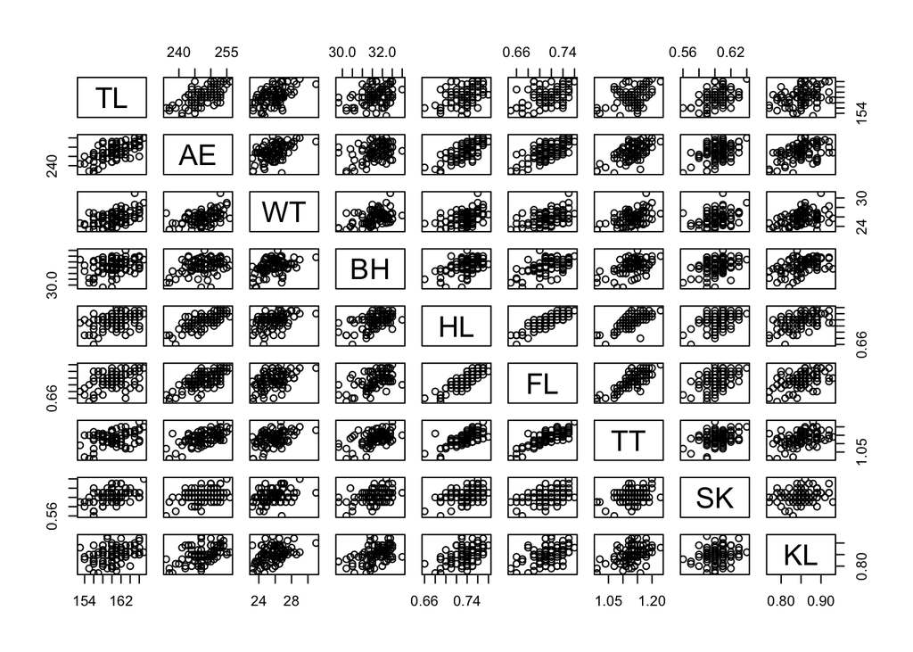

```r
pairs(df[3:11])
```

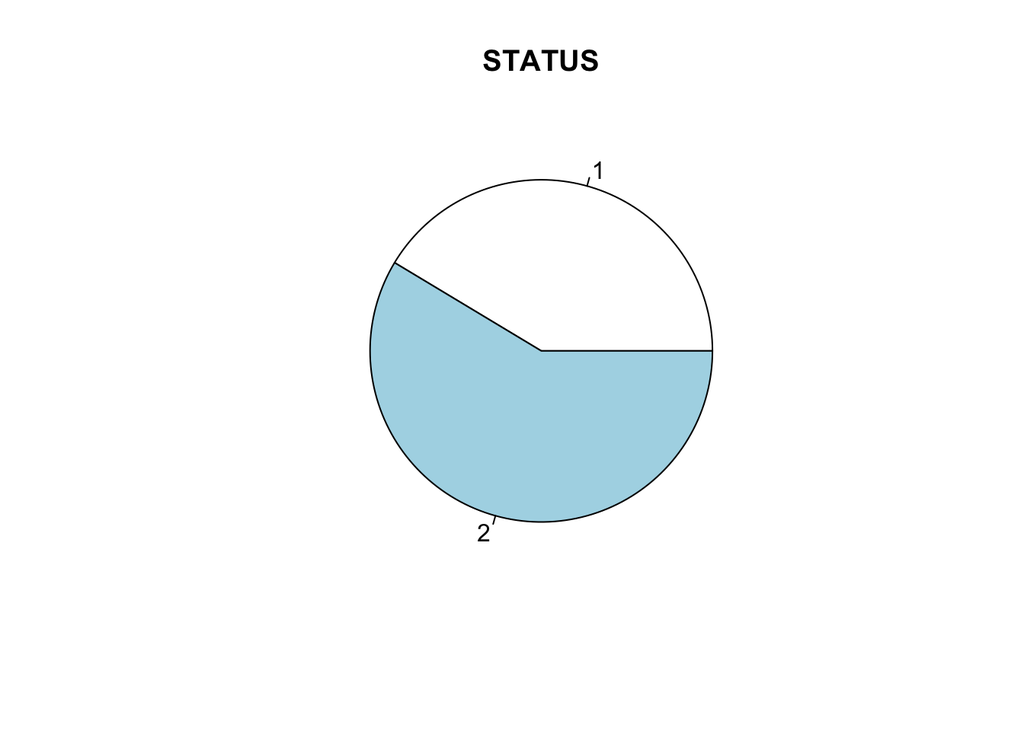

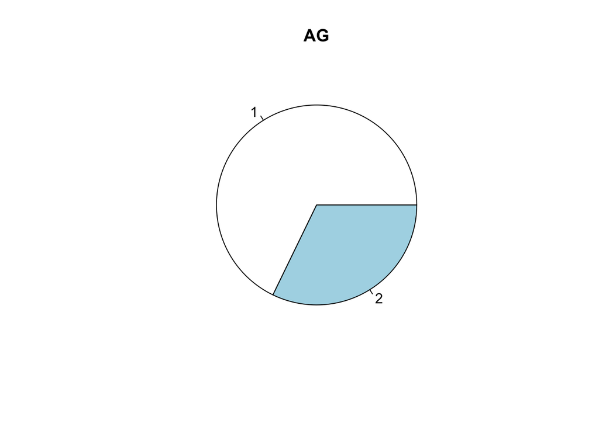

```r
for (i in 1:2){
    num = as.numeric(df[,i])
    cou = table(num)
    pie(cou, main=names(df)[i])
}
```

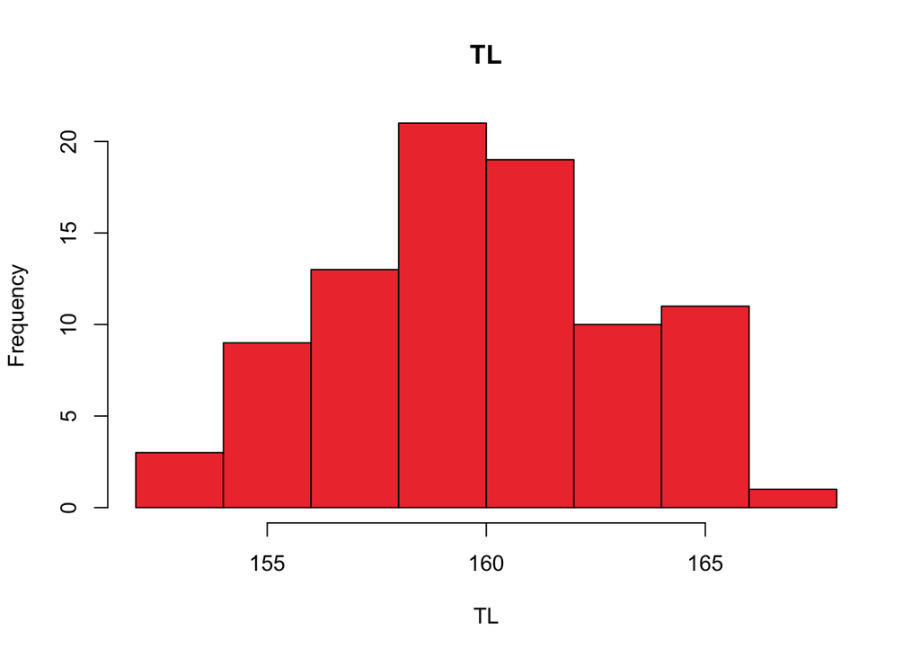

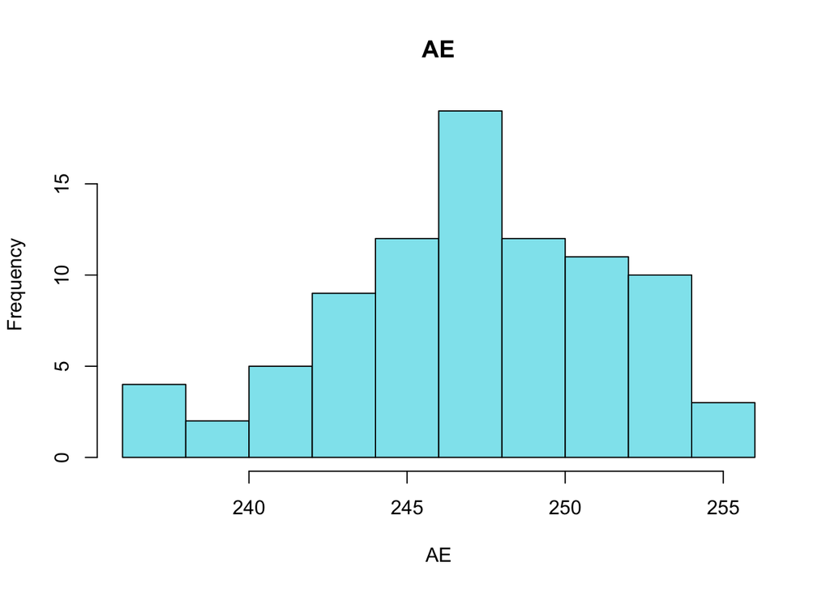

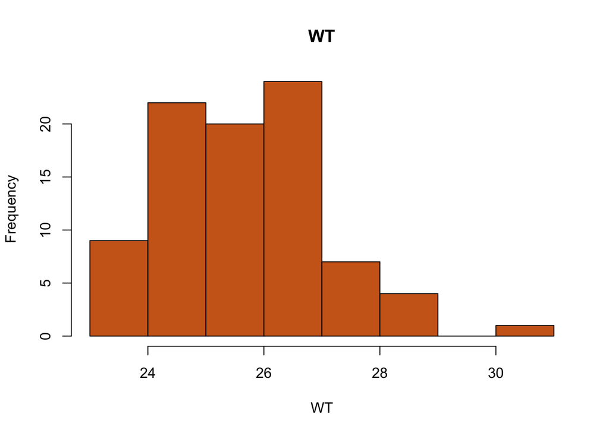

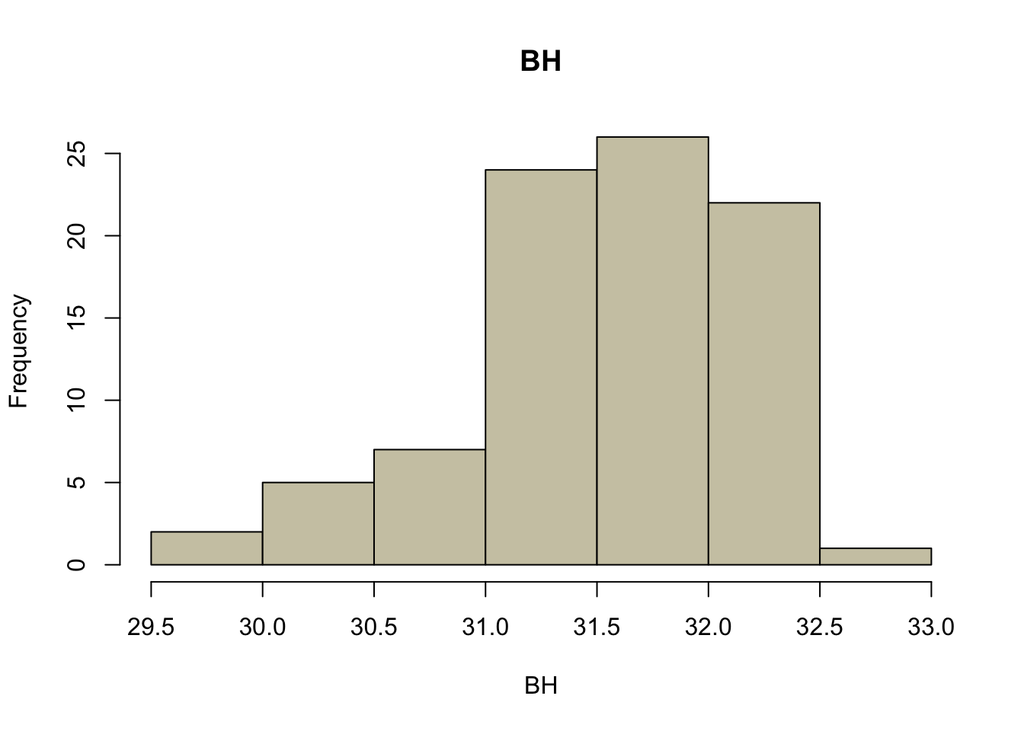

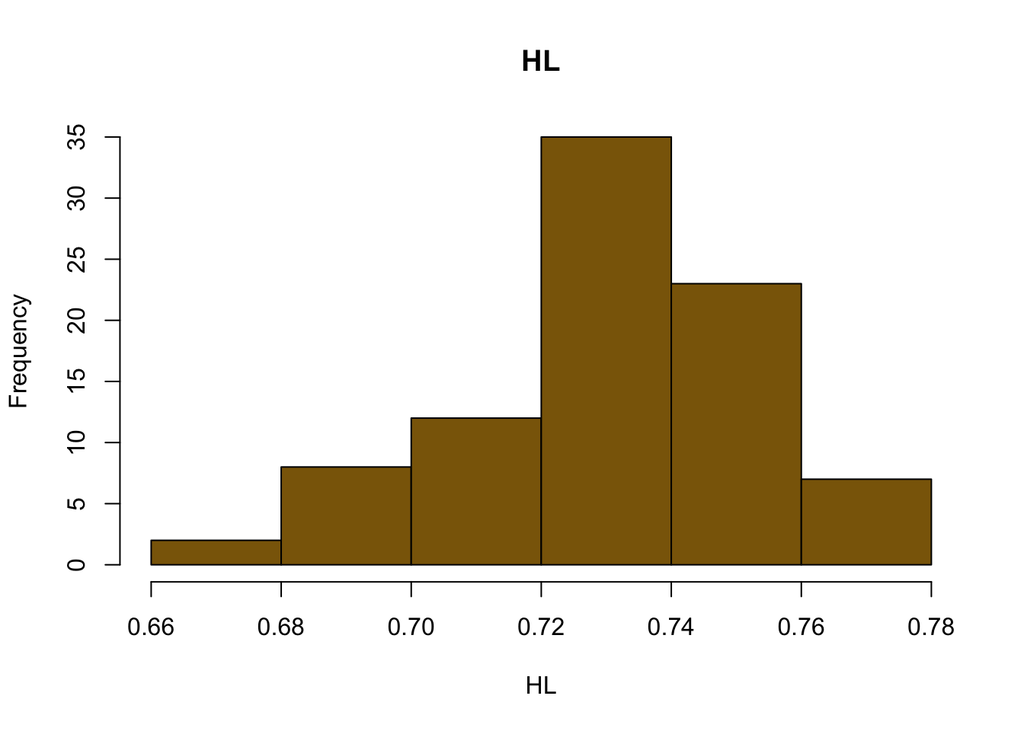

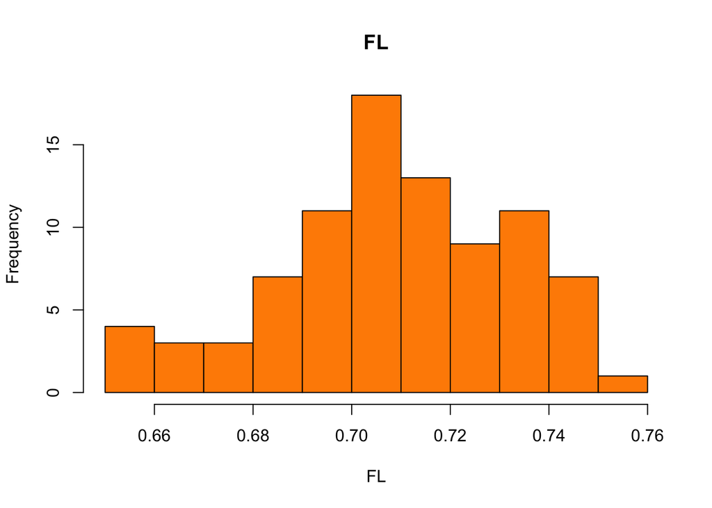

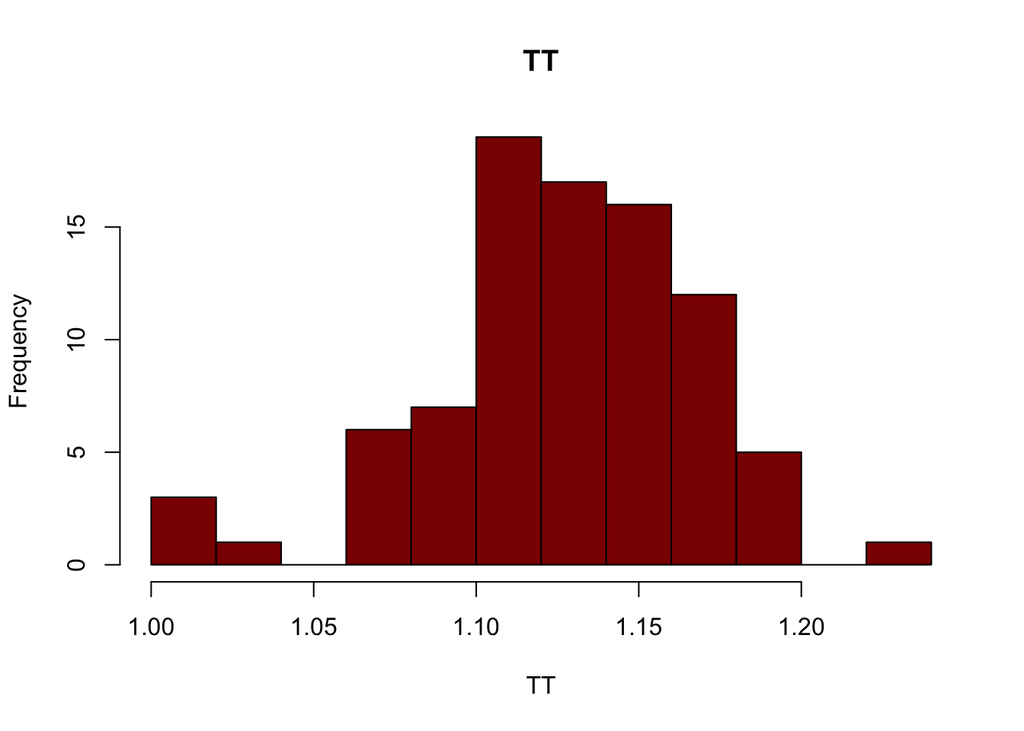

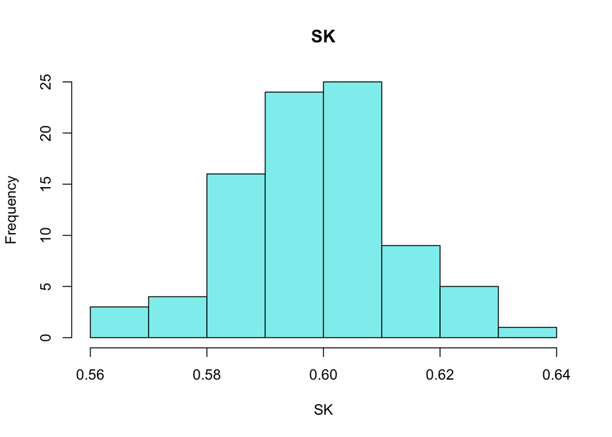

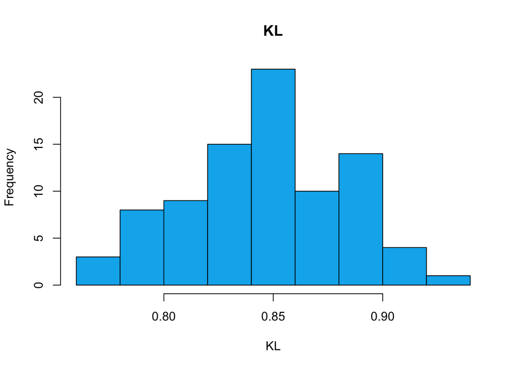

```r
for (i in 3:dim(df)[2]){
    hist(df[,i], main=names(df)[i], xlab=names(df)[i], col=colors(1)[10*i])
}
```

There appears to be a great degree of co-linearity between many of the factors. Each factor is aproximately normal.

# Models and methods used

# Data transformation

First, we normalize the data by centering each column at zero and scaling each column by its individual standard deviation. This normalization is reasonable because most explanatory factors are aproximately normal.

```r
nf = df
nf[,1] = as.numeric(nf[,1])-1   # Use 1's for survive, 0's for died
nf[,2:11] = scale(nf[,2:11])    # Standardize other metrics
```

# Initial model

```r
fit.full = glm(STATUS~., data=nf)
summary(fit.full)
```

```
##
## Call:
## glm(formula = STATUS ~ ., data = nf)
##
## Deviance Residuals:
##      Min        1Q    Median        3Q       Max
## -0.87136  -0.26755   0.02935   0.26315   0.68093
##
## Coefficients:
##              Estimate Std. Error t value Pr(>|t|)
## (Intercept)  0.586207   0.041859  14.004  < 2e-16 ***
## AG           0.002137   0.043765   0.049  0.96118
## TL          -0.299871   0.060271  -4.975 3.94e-06 ***
## AE           0.061944   0.077445   0.800  0.42629
## WT          -0.159133   0.054918  -2.898  0.00491 **
## BH           0.030039   0.055468   0.542  0.58971
## HL           0.146497   0.090605   1.617  0.11005
## FL          -0.016105   0.091011  -0.177  0.86001
## TT           0.025365   0.073176   0.347  0.72982
## SK           0.071317   0.050154   1.422  0.15913
## KL           0.095969   0.051927   1.848  0.06847 .
## ---
## Signif. codes:  0 '***' 0.001 '**' 0.01 '*' 0.05 '.' 0.1 ' ' 1
##
## (Dispersion parameter for gaussian family taken to be 0.1524394)
##
##     Null deviance: 21.103  on 86  degrees of freedom
## Residual deviance: 11.585  on 76  degrees of freedom
## AIC: 95.489
##
## Number of Fisher Scoring iterations: 2
```

```r
X = as.matrix(nf[,2:11])
Y = as.matrix(nf[1])
S = t(X)%*%X
L = eigen(S)
L$values
```

```
##  [1] 424.83505  90.52633  80.45301  66.14005  61.95572  46.64495  36.78528
##  [8]  23.76740  17.61074  11.28145
```

```r
ev3percent = sum(L$values[1:3])/sum(L$values)
```

# Diagnostics

First, we examine the VIF to determine whether multi-collinearity is present. Then we select an appropriate lasso parameter and apply constrained generalized linear regression.

```r
fit.full.vif = vif(glm(STATUS~.*., family=binomial(), data=nf))
propG10 = sum(fit.full.vif>10)/length(fit.full.vif)*100
fit.full.vif
```

```
##         AG         TL         AE         WT         BH         HL
##  458.47440  201.17757  586.55142  139.56295  136.01297  510.50995
##         FL         TT         SK         KL      AG:TL      AG:AE
##  410.60604  320.03815   40.85261  243.52199  204.51853 1895.08968
##      AG:WT      AG:BH      AG:HL      AG:FL      AG:TT      AG:SK
##  238.94168  179.23458 1263.16475  349.51719 1179.44189   65.50558
##      AG:KL      TL:AE      TL:WT      TL:BH      TL:HL      TL:FL
##   72.93839  228.30577  495.03810  411.41100  427.75218 1389.45698
##      TL:TT      TL:SK      TL:KL      AE:WT      AE:BH      AE:HL
##  886.21253 1129.98765  164.05982  722.32357  509.70325 3301.78855
##      AE:FL      AE:TT      AE:SK      AE:KL      WT:BH      WT:HL
## 1072.78350  876.13120  798.06523  374.74133  434.25800  638.38214
##      WT:FL      WT:TT      WT:SK      WT:KL      BH:HL      BH:FL
## 3901.30166  595.26294   67.99244  583.03389  995.23692 1488.57297
##      BH:TT      BH:SK      BH:KL      HL:FL      HL:TT      HL:SK
## 1258.46724  248.08381  153.88553  624.16517 3768.39344 1659.52514
##      HL:KL      FL:TT      FL:SK      FL:KL      TT:SK      TT:KL
##  423.56320 2889.52598 2297.36728 1234.51279  829.17769 2048.41494
##      SK:KL
##  225.28567
```

As can be seen above, $100$% of the factors have inflation factors larger than 10. This evidence indicates that constrained regression is appropriate here.

# Model selection

```r
lm = c()
for (i in 1:30){
    lm = c(lm, cv.glmnet(X,Y)$lambda.min)
}
lambda.min = mean(lm)
```

The best cross validated regression constraint parameter is $\lambda=0.0178413$. Following are the model coefficients with the minimized regression constraint parameter.

# Recommended final model

```r
fit = glmnet(X,Y, family="binomial")
cvfit = cv.glmnet(X,Y, family="binomial")
coef(cvfit, s = lambda.min)
```

```
## 11 x 1 sparse Matrix of class "dgCMatrix"
##                       1
## (Intercept)  0.52699286
## AG           .
## TL          -1.58650614
## AE           0.02154425
## WT          -0.73585633
## BH           0.16733707
## HL           1.00993743
## FL           .
## TT           0.04685837
## SK           0.17391390
## KL           0.53125641
```

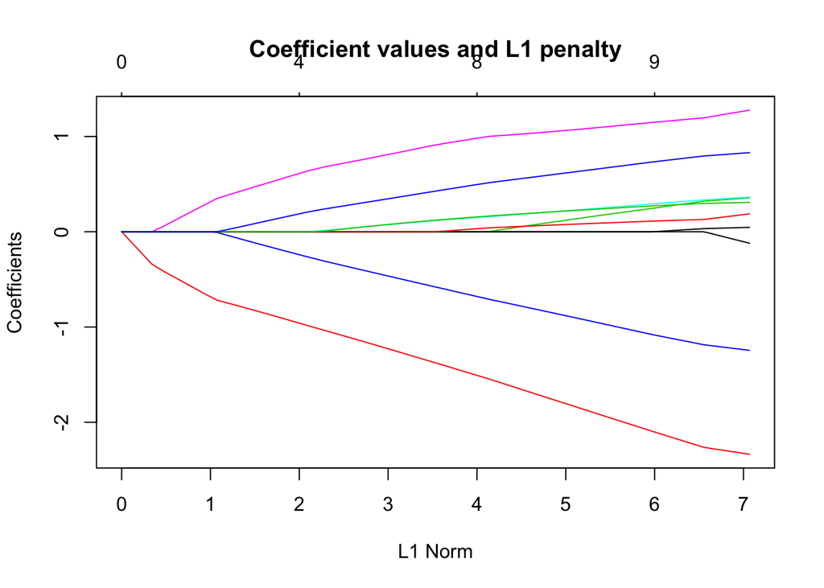

```r
plot(fit, main="Coefficient values and L1 penalty")
```

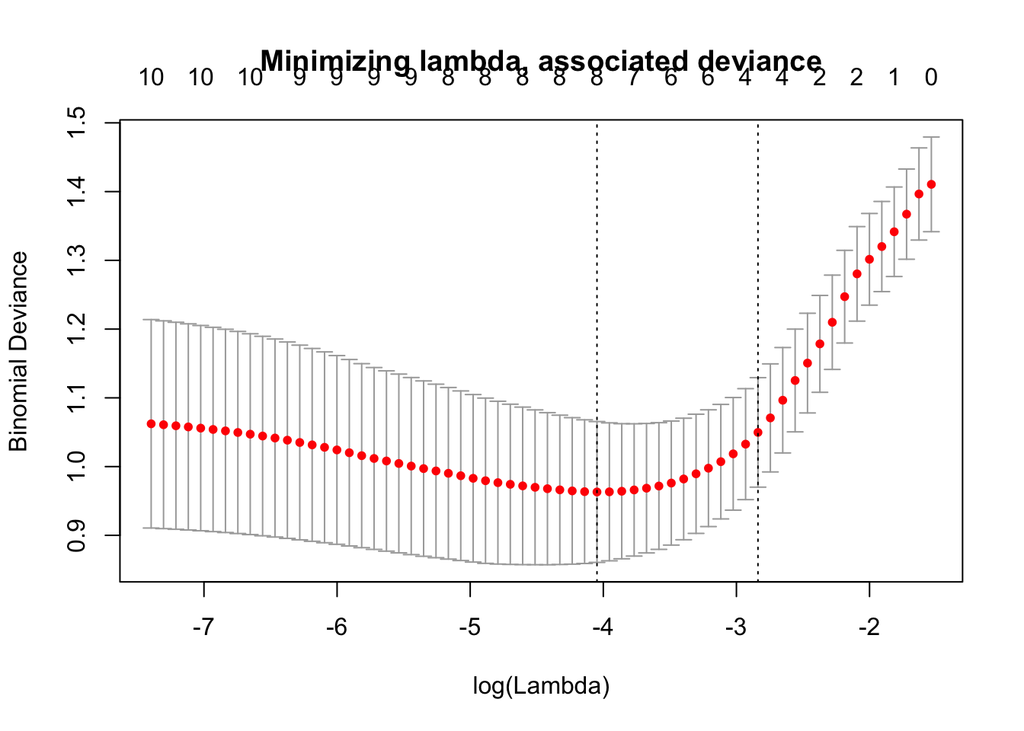

```r
plot(cvfit, main="Minimizing lambda, associated deviance")
```